# DATA 624 - HOMEWORK 3

```r
library(tidyverse)
library(fpp2)
library(readxl)
library(rio)
library(gridExtra)
library(ggpubr)
library(ggthemes)
library(seasonal)
```

# 1 Question - 6.2

**The plastics data set consists of the monthly sales (in thousands) of product A for a plastics manufacturer for five years.**

**(a.) Plot the time series of sales of product A. Can you identify seasonal fluctuations and/or a trend-cycle?**

**Answer:**

The autoplot shows a significantinscreasing trend.

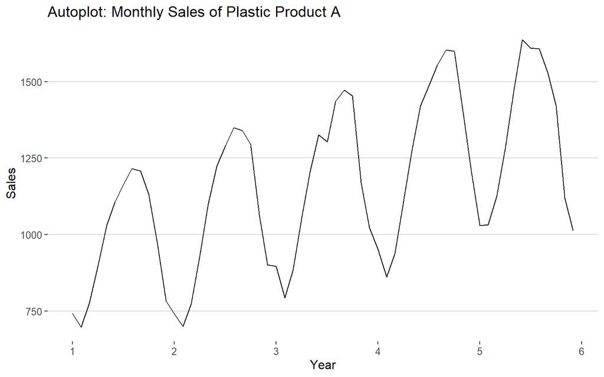

```r
autoplot(plastics) +
  xlab("Year") + ylab("Sales") +
  ggtitle("Autoplot: Monthly Sales of Plastic Product A") +
  theme_hc()
```

The ggsubseriesplot presents a significant normal seasonal fluctuations.

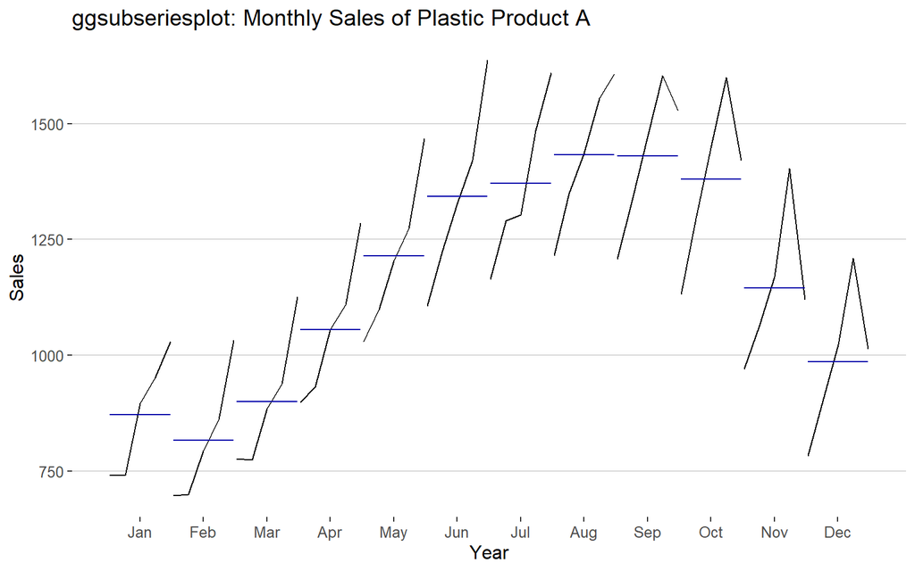

```r
ggsubseriesplot(plastics) +
  xlab("Year") + ylab("Sales") +
  ggtitle("ggsubseriesplot: Monthly Sales of Plastic Product A") +
  theme_hc()
```

**(b.) Use a classical multiplicative decomposition to calculate the trend-cycle and seasonal indices.**

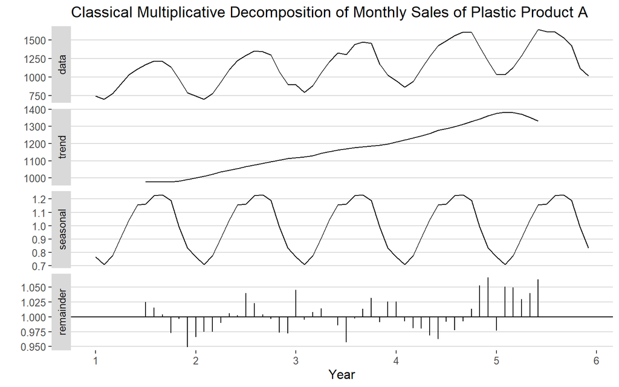

```r
plastics %>% decompose(type="multiplicative") %>%
  autoplot() + xlab("Year") +
  ggtitle("Classical Multiplicative Decomposition of Monthly Sales of Plastic Product A") +
  theme_hc()
```

**(c.) Do the results support the graphical interpretation from part a?**

**Answer:** Yes. The result of classical multiplicative decomposition supports the graphical interpretation from part A.

**(d.) Compute and plot the seasonally adjusted data.**

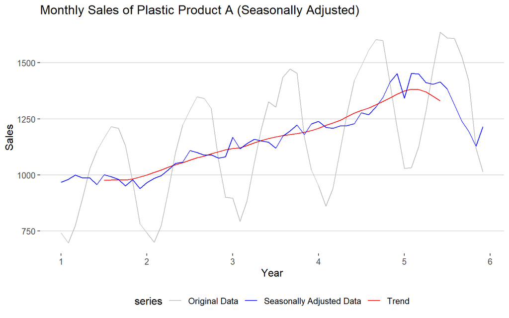

```r
fit <- plastics %>% decompose(type="multiplicative")
autoplot(plastics, series="Original Data") +
  autolayer(trendcycle(fit), series="Trend") +
  autolayer(seasadj(fit), series="Seasonally Adjusted Data") +
  xlab("Year") + ylab("Sales") +
  ggtitle("Monthly Sales of Plastic Product A (Seasonally Adjusted)") +
  scale_color_manual(values=c("gray", "blue", "red"),
                     breaks=c("Original Data", "Seasonally Adjusted Data", "Trend")) +
  theme_hc()
```

(e.) Change one observation to be an outlier (e.g., add 500 to one observation), and recompute the seasonally adjusted data. What is the effect of the outlier?